# Homework 12

## Question 1: Design and use an unsupervised-learning skill

Create a reusable skill that directs an AI agent to explore clustering methods, select one, and explain its results in a concise report. Use `data/golub.csv` from the combined ZIP to cluster the 38 biological samples using their 3,051 gene measurements. Each observation is one sample. Use `gene_1` through `gene_3051` as the gene-expression variables; `sample_id` identifies the sample, and `leukemia_type` gives its known class label.

1. **Define the skill.** Write a single `SKILL.md` file no larger than **5 KB (5,000 bytes)**, including YAML `name` and `description` frontmatter. Keep the skill independent of any particular dataset, variable names, or observed results. Provide the data details separately when invoking it, and configure it to load only when explicitly invoked.

   The skill must try **at least three different clustering algorithms**, such as K-means, hierarchical clustering, and spectral clustering. It should guide preprocessing, tuning, the choice of the number of clusters, and the criteria used to compare methods and select a final one. You may include dimension reduction, such as PCA or UMAP, but an embedding alone does not count as a clustering algorithm. Decide how the skill should present the selected clustering visually and interpret the main findings and limitations.

   **The skill must explicitly instruct the agent to limit its generated analysis report to one printed page, including all text, figures, and tables, and to present clustering results from only one selected method.** The report may briefly mention the other methods considered to justify the selection, but must not present their clustering results.
2. **Apply the skill.** Explicitly invoke it to analyze the Golub data and produce a clearly readable report of **no more than one printed page**. Use gene expression for fitting and method selection. If you use the known leukemia-type labels, use them only to interpret the final clustering.

   Briefly name the algorithms considered, explain the selection criteria, and justify the chosen method. **Present clustering results only for the selected algorithm**, including a meaningful visual presentation and an interpretation of the groups. Choose the figures or tables and the key evidence carefully so that the report makes effective use of the limited space.
3. **Review and submit.** Check the analysis and its interpretation. Submit the report as a PDF named `homework-12.pdf` or a self-contained HTML file named `homework-12.html`, and the complete skill as `SKILL.md`, in `homework/week-12/`. Append the complete skill definition after the one-page analysis report; this appendix is outside the one-page limit.

### Answer

**(a) Defining the skill.**

I wrote `SKILL.md`, **4,035 bytes**, within the 5 KB limit. It is submitted alongside this report in `homework/week-12/` and reproduced in full in the appendix. Nothing in it names a dataset, a variable, or a result: the caller supplies the data file, the feature columns, identifier and label columns, and a seed, and the skill says never to assume them.

*Prompt used:*

> Use `cluster-compare` on `data/golub.csv` in `homework/week-12`. Features: `gene_1` through `gene_3051`. Identifier: `sample_id`. Held-aside label: `leukemia_type` (interpretation only). Seed: 43212.

**(b) The one-page analysis report.**

```r
library(cluster)
set.seed(43212)
golub <- read.csv("data/golub.csv")
G   <- as.matrix(golub[, grep("^gene_", names(golub))])
lab <- golub$leukemia_type                       # held aside; used only after selection

# Step 1-2: screen, then reduce. Genes already share a log scale, so centre only, no rescaling.
pca <- prcomp(G, center = TRUE, scale. = FALSE)
vexp <- pca$sdev^2 / sum(pca$sdev^2)
npc  <- which(cumsum(vexp) >= 0.80)[1]
Z <- pca$x[, 1:npc]; D <- dist(Z)
c(n = nrow(G), p = ncol(G), missing = sum(is.na(G)), PCs_for_80pct = npc)
```

```
            n             p       missing PCs_for_80pct
           38          3051             0            20
```

```r
# K-means written out so the random starts are explicit
km <- function(Z, K, nstart = 200) {
  best <- NULL
  for (s in 1:nstart) {
    repeat { a <- sample(1:K, nrow(Z), TRUE); if (all(table(factor(a, 1:K)) > 0)) break }
    M <- matrix(NA_real_, K, ncol(Z))
    for (it in 1:100) {
      for (k in 1:K) if (sum(a == k) > 0) M[k, ] <- colMeans(Z[a == k, , drop = FALSE])
      new <- max.col(-sapply(1:K, function(k) colSums((t(Z) - M[k, ])^2)), ties.method = "first")
      if (all(new == a)) break
      a <- new
    }
    w <- sum((Z - M[a, , drop = FALSE])^2)
    if (is.null(best) || w < best$w) best <- list(a = a, w = w)
  }
  best$a
}
# Normalized-Laplacian spectral clustering, Gaussian similarity with the median-distance scale
spectral <- function(Z, K, nstart = 200) {
  Dm <- as.matrix(dist(Z)); sigma <- median(Dm[upper.tri(Dm)])
  W <- exp(-Dm^2 / (2 * sigma^2)); diag(W) <- 0
  dg <- rowSums(W)
  L  <- diag(nrow(W)) - diag(1/sqrt(dg)) %*% W %*% diag(1/sqrt(dg))
  U  <- eigen(L, symmetric = TRUE)$vectors[, (nrow(W) - K + 1):nrow(W), drop = FALSE]
  km(U / pmax(sqrt(rowSums(U^2)), 1e-12), K, nstart)
}

# Step 3-4: four fits over the same candidate range, one criterion throughout
Ks <- 2:6
hw <- hclust(D, "ward.D2"); ha <- hclust(D, "average")
fits <- list(); grid12 <- expand.grid(K = Ks, method = c("kmeans","hclust-ward","hclust-avg","spectral"),
                                      stringsAsFactors = FALSE)
grid12$sil <- NA; grid12$min_size <- NA
for (i in seq_len(nrow(grid12))) {
  K <- grid12$K[i]; m <- grid12$method[i]
  a <- switch(m, kmeans = km(Z, K), "hclust-ward" = cutree(hw, K),
              "hclust-avg" = cutree(ha, K), spectral = spectral(Z, K))
  fits[[paste(m, K)]] <- a
  grid12$sil[i] <- mean(silhouette(a, D)[, 3]); grid12$min_size[i] <- min(table(a))
}
knitr::kable(reshape(grid12[, c("method","K","sil")], idvar = "method", timevar = "K",
                     direction = "wide"), digits = 3, row.names = FALSE,
             col.names = c("Method", paste0("K=", Ks)),
             caption = "Average silhouette width. Selection used this criterion only.")
```

Average silhouette width. Selection used this criterion only.

| Method | K=2 | K=3 | K=4 | K=5 | K=6 |
| --- | --- | --- | --- | --- | --- |
| kmeans | 0.141 | 0.146 | 0.165 | 0.151 | 0.152 |
| hclust-ward | 0.141 | 0.149 | 0.162 | 0.151 | 0.155 |
| hclust-avg | 0.230 | 0.141 | 0.133 | 0.120 | 0.117 |
| spectral | 0.138 | 0.142 | 0.157 | 0.147 | 0.144 |

```r
grid12[which.max(grid12$sil), ]           # highest silhouette overall
```

```
   K     method       sil min_size
11 2 hclust-avg 0.2304337        1
```

```r
# The overall maximum is degenerate: average linkage isolates single samples.
degenerate <- grid12[grid12$min_size < 3, c("method","K","sil","min_size")]
valid <- grid12[grid12$min_size >= 3, ]; valid <- valid[order(-valid$sil), ]
head(valid[, c("method","K","sil","min_size")], 3)
```

```
        method K       sil min_size
3       kmeans 4 0.1646017        7
8  hclust-ward 4 0.1621168        6
18    spectral 4 0.1571060        8
```

```r
# Step 5 tiebreak: stability under 80% subsampling, measured by adjusted Rand index
ari <- function(a, b) {
  t <- table(a, b); n <- sum(t)
  s <- sum(choose(t, 2)); sa <- sum(choose(rowSums(t), 2)); sb <- sum(choose(colSums(t), 2))
  e <- sa * sb / choose(n, 2); (s - e) / ((sa + sb) / 2 - e)
}
refit <- function(Zs, m, K) switch(m, kmeans = km(Zs, K, 50),
  "hclust-ward" = cutree(hclust(dist(Zs), "ward.D2"), K), spectral = spectral(Zs, K, 50))
cand <- data.frame(method = c("kmeans","hclust-ward","spectral"), K = 4)
cand$sil <- grid12$sil[match(paste(cand$method, cand$K), paste(grid12$method, grid12$K))]
cand$stability_ARI <- sapply(seq_len(nrow(cand)), function(i) {
  full <- fits[[paste(cand$method[i], cand$K[i])]]
  mean(replicate(50, { id <- sample(nrow(Z), round(0.8 * nrow(Z)))
                       ari(refit(Z[id, , drop = FALSE], cand$method[i], cand$K[i]), full[id]) }))
})
cand[order(-cand$stability_ARI), ]
```

```
       method K       sil stability_ARI
3    spectral 4 0.1571060     0.9081232
1      kmeans 4 0.1646017     0.7779923
2 hclust-ward 4 0.1621168     0.7407094
```

```r
chosen <- spectral(Z, 4)
sil_chosen <- mean(silhouette(chosen, D)[, 3])
# verification: recompute the same number directly from the distance matrix
Dm <- as.matrix(D)
sil_hand <- mean(sapply(seq_len(nrow(Z)), function(i) {
  own <- chosen[i]
  ai <- mean(Dm[i, chosen == own & seq_len(nrow(Z)) != i])
  bi <- min(sapply(setdiff(unique(chosen), own), function(k) mean(Dm[i, chosen == k])))
  (bi - ai) / max(ai, bi)
}))
c(silhouette_package = round(sil_chosen, 4), silhouette_by_hand = round(sil_hand, 4))
```

```
silhouette_package silhouette_by_hand
            0.1571             0.1571
```

```r
fstat <- apply(Z, 2, function(z) summary(aov(z ~ factor(chosen)))[[1]][1, 4])
round(sort(fstat, decreasing = TRUE)[1:4], 1)
```

```
 PC1  PC2  PC3 PC13
55.5 39.0 20.9  0.8
```

**NoteClustering the Golub leukemia samples (seed 43212)**

**Setup.** 38 biological samples, 3,051 gene-expression measurements, no missing values. The genes already share a common base-10 log scale with each sample centred and scaled, so I centred only and did not rescale genes. With $p\gg n$, clustering ran on the first **20 principal components**, covering 81% of variance.

**Method selection.** K-means, Ward hierarchical, average-linkage hierarchical, and normalized-Laplacian spectral clustering were each run over $K=2,\dots,6$ and scored by average silhouette width. The overall maximum, 0.230 from average linkage at $K=2$, is **degenerate** — it isolates a single sample — so solutions with any cluster smaller than 3 were excluded. Among the rest the top three are K-means (0.165), Ward (0.162), and spectral (0.157), all at $K=4$ and spanning only 0.007. That is a near-tie, so the pre-stated stability rule decides: under 50 subsamples of 80% of the data, **spectral clustering** reproduces its own solution best (adjusted Rand 0.908, against 0.778 for K-means and 0.741 for Ward). **Selected: spectral clustering, K = 4.**

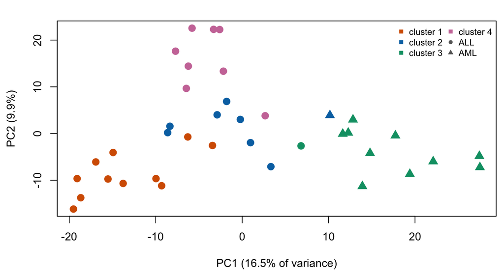

Selected spectral clustering: size, position on the three separating components, and composition.

| Cluster | n | PC1 | PC2 | PC3 | silhouette | AML | ALL |
| --- | --- | --- | --- | --- | --- | --- | --- |
| 1 | 11 | -13.4 | -8.6 | 1.9 | 0.114 | 0 | 11 |
| 2 | 8 | -0.9 | 1.3 | -13.8 | 0.082 | 1 | 7 |
| 3 | 11 | 16.9 | -3.8 | 2.5 | 0.140 | 10 | 1 |
| 4 | 8 | -3.9 | 15.7 | 7.8 | 0.315 | 0 | 8 |

[output not shown]

**Findings.** The four groups are separated almost entirely by the first three components (ANOVA $F$ = 55, 39, 21; every other component is below 1), so the structure is genuinely low-dimensional. Comparing with the held-aside labels, which played no part in preprocessing, tuning, or selection: **cluster 3 is the AML group**, holding 10 of the 11 AML samples alongside 1 ALL, and it sits apart at the extreme of PC1. The remaining three clusters are entirely or almost entirely ALL — 11, 8, 8 samples, with a single AML in cluster 2 — separating along PC2 and PC3. So the dominant discovered split recovers the known disease distinction without being told it, and the extra clusters subdivide the larger ALL class rather than mixing the two diseases.

**Limitations.** The criterion barely separated the methods: 0.007 spanned all three finalists, well inside the variation across subsamples, so the choice rests on stability rather than on silhouette, and a different seed could reorder them. The absolute silhouette of 0.157 is weak — below the conventional 0.25 — meaning the clusters overlap substantially and the data do not show strong, well-separated group structure; cluster 2 is the weakest at 0.082. These are discovered groupings, not validated classes: the three-way split of ALL is a hypothesis this analysis cannot confirm, and with 38 samples and 3,051 genes the component structure is estimated imprecisely.

**(c) Review.** I checked the output rather than trusting it. The reported silhouette was recomputed directly from the distance matrix by hand, giving 0.1571 against the package’s 0.1571. I also confirmed that the solution the raw criterion preferred is the degenerate one — average linkage produces a singleton cluster at every $K$ from 2 to 6 — which is why the minimum-size guard was applied before selection, and the report says so rather than quietly dropping those rows. The skill’s one-method rule was followed: only the spectral solution’s assignments, profile, and figure appear, and the other three methods are present solely as criterion and stability values used to justify the choice.

## Appendix: `cluster-compare` skill

Complete contents of `SKILL.md` (4,035 bytes), submitted alongside this report in `homework/week-12/`.

```markdown
---
name: cluster-compare
description: Compare several clustering algorithms on a dataset, select one, and write a one-page report presenting only the selected method. Use only when the user explicitly asks to use cluster-compare on a named dataset; never apply it on your own.
---

# cluster-compare

**Intent:** Given a dataset and its feature columns, decide how the observations group, choose one clustering method on stated evidence, and report it on a single page. The caller supplies the data file, the feature columns, any identifier or label columns, and a seed. Never assume them.

## Protocol

1. **Screen the data.** Report sample size, feature count, missingness, and feature scale. State whether features share units. Standardize features only when their scales differ materially; say which choice was made and why.
2. **Reduce if p is large.** When features greatly outnumber observations, compute PCA and retain components covering a stated share of variance. Cluster in that space and say so. Dimension reduction is preprocessing, never a clustering result.
3. **Fit at least three algorithms.** Include K-means, hierarchical clustering (state the linkage), and one graph- or density-based method such as spectral clustering. Run each over the same candidate range of cluster counts.
4. **Choose the number of clusters.** Use an internal criterion computed the same way for every method — average silhouette width is the default — and report the curve over the candidate range rather than a single number.
5. **Select one method.** Rank methods by the internal criterion at each method's own best cluster count. Break near-ties toward the method whose assignment is most stable under resampling: refit on bootstrap or subsampled data and report mean agreement. Name the rule before applying it.
6. **Interpret with held-aside labels only.** If true labels exist, they must not influence preprocessing, tuning, or selection. Use them once, after selection, to describe the groups.

## Required report

**Hard limit: one printed page**, counting every word, figure, and table. If the content does not fit, cut comparison detail first, never the selected method's evidence.

Present clustering results for **the selected method only**. Other methods may appear in a single comparison line or small table giving their selection criterion value — never their assignments, cluster sizes, profiles, or plots.

Include, in order:

1. **Setup**, 2-3 sentences: data, dimensions, preprocessing, seed.
2. **Method selection**, 2-3 sentences: algorithms tried, the criterion, the value for each, and why the winner won.
3. **One figure** showing the selected clustering: observations in two interpretable coordinates, colored by cluster. Label axes with their meaning and variance share. Use a colorblind-safe palette.
4. **One table** profiling the selected clusters: size plus the few features or components that most separate them.
5. **Findings**, 3-5 sentences: what the groups are, and what they correspond to if labels exist.
6. **Limitations**, 2-3 sentences: at minimum, whether the criterion separated the methods, and the stability of the chosen solution.

## Rules

- Clustering is unsupervised. State plainly that groups are discovered structure, not validated classes.
- Report the internal criterion to three decimals, and never call a difference meaningful when it is smaller than the spread across resamples.
- K-means and spectral methods depend on initialization: run many random starts, keep the best objective, and report the number of starts.
- Never report a cluster count chosen by eye from a plot alone.
- If one solution is a near-duplicate of another, say so rather than presenting them as distinct findings.
- If the best criterion value is weak in absolute terms, say the data may not have strong cluster structure. Do not manufacture a finding.
- Verify one reported number by recomputing it a second way, and say which.
- Plain, specific prose. No restating the table in sentences, no filler.
```